# Exp8_MLM report

Mrudula & Carina

15 June,2021

**This report highlights the results from the Multi level analysis for Experiment 8 and only for participants without awareness.** Data from experiment 8 has already been prepared with the relevant factors such as :

1. Distance: How far ago was the last occurence
2. Distance_type: Was the last occurence a SingleD or a MultipleD trial. If it is MultipleD then Distance_type is 1 and if it is SingleD then it is 2
3. ResponseRel: Whether the previous response was repeated or changed.
4. Validity and Saliency factors were converted to numeric: Valid trials are 1, and invalid and -1 similarly Salient is 1 and nonsalient is -1
5. Only the RTs of SingleD trials were used for analysis

The prepared dataset is saved as *Exp8_withoutawareness.csv* and is loaded to perform the MLM.

### Data Preparation and cleaning

This data is further edited to be prepared for analysis in the following ways

1. Create numeric factor for Previous Response : RR (1) and RC(2)
2. Removing compound trials and choosing only SingleD trials that were used for analysis
3. Centering predictors : within participants as level 1 predictors are participants. This is done using the formula $cwp = Actual value - mean$
   - Previous Response_cwp
   - Distance_cwp
   - Distance_Type_cwp

These are then merged with the main dataframe

# Multi Level Analysis

## 1. Model 1 - similar to ANOVA data

This model replicates the ANOVa on the aggregated data used in the standard analysis. The factors used are:

- Validity: valid (1) and invalid(-1)
- Saliency: Salient(1) and nonsalient(-1)
- Val*Sal interaction: indicating overshadowing if validity effect is larger for salient vs nonsalient trials

### 1. with RTs as dependant variable

```r
randomSlopes_m1<-lmer(RT_io~1+val*sal + (1+val*sal|participant),
                      data=raw.data,
                      REML=F,
                      na.action = "na.omit")


tab_model(randomSlopes_m1, show.se = TRUE,show.stat = TRUE, show.ci = FALSE,show.aic = TRUE, show.loglik = TRUE,
                  dv.labels = "Reaction Time")
```

|  | Reaction Time |  |  |  |
| --- | --- | --- | --- | --- |
| Predictors | Estimates | std. Error | Statistic | p |
| (Intercept) | 579.68 | 10.47 | 55.35 | **<0.001** |
| val | 4.09 | 2.53 | 1.61 | 0.106 |
| sal | -2.77 | 2.30 | -1.20 | 0.229 |
| val * sal | 1.67 | 2.31 | 0.72 | 0.471 |
| Random Effects |  |  |  |  |
| σ<sup>2</sup> | 13849.97 |  |  |  |
| τ<sub>00</sub> <sub>participant</sub> | 4285.05 |  |  |  |
| τ<sub>11</sub> <sub>participant.val</sub> | 50.54 |  |  |  |
| τ<sub>11</sub> <sub>participant.sal</sub> | 5.31 |  |  |  |
| τ<sub>11</sub> <sub>participant.val:sal</sub> | 7.45 |  |  |  |
| ρ<sub>01</sub> | 0.85 |  |  |  |
|  | -0.88 |  |  |  |
|  | 0.98 |  |  |  |
| ICC | 0.26 |  |  |  |
| N <sub>participant</sub> | 41 |  |  |  |
| Observations | 7302 |  |  |  |
| Marginal R<sup>2</sup> / Conditional R<sup>2</sup> | 0.000 / 0.264 |  |  |  |
| AIC | 90557.871 |  |  |  |
| log-Likelihood | -45263.935 |  |  |  |

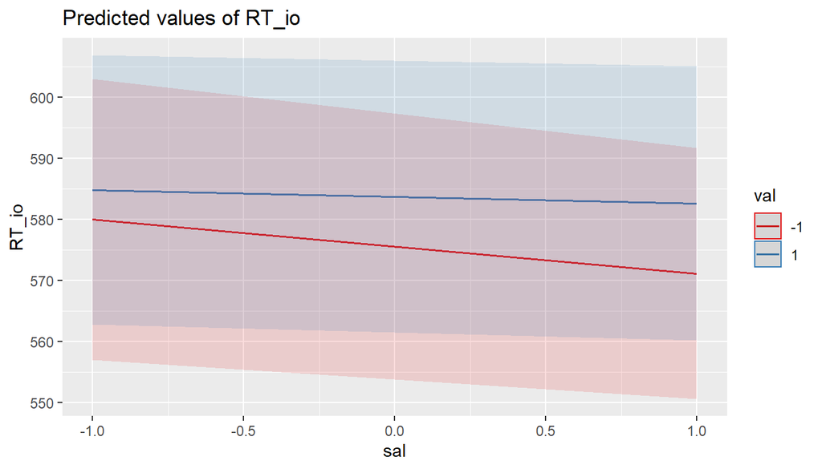

```r
plot_model(randomSlopes_m1, type = "pred", terms = c("sal", "val[minmax]"))
```

```r
summary(randomSlopes_m1)
```

```
## Linear mixed model fit by maximum likelihood . t-tests use Satterthwaite's
##   method [lmerModLmerTest]
## Formula: RT_io ~ 1 + val * sal + (1 + val * sal | participant)
##    Data: raw.data
##
##      AIC      BIC   logLik deviance df.resid
##  90557.9  90661.3 -45263.9  90527.9     7287
##
## Scaled residuals:
##     Min      1Q  Median      3Q     Max
## -3.9030 -0.6435 -0.1155  0.4888  5.8977
##
## Random effects:
##  Groups      Name        Variance  Std.Dev. Corr
##  participant (Intercept)  4285.051  65.460
##              val            50.545   7.109   0.85
##              sal             5.308   2.304  -0.88 -0.49
##              val:sal         7.451   2.730   0.98  0.71 -0.96
##  Residual                13849.972 117.686
## Number of obs: 7302, groups:  participant, 41
##
## Fixed effects:
##             Estimate Std. Error      df t value Pr(>|t|)
## (Intercept)  579.681     10.473  40.988  55.349   <2e-16 ***
## val            4.085      2.531  44.410   1.614    0.114
## sal           -2.772      2.302 402.571  -1.204    0.229
## val:sal        1.667      2.314 428.103   0.720    0.472
## ---
## Signif. codes:  0 '***' 0.001 '**' 0.01 '*' 0.05 '.' 0.1 ' ' 1
##
## Correlation of Fixed Effects:
##         (Intr) val    sal
## val      0.209
## sal     -0.134 -0.032
## val:sal  0.176  0.055 -0.800
## convergence code: 0
## boundary (singular) fit: see ?isSingular
```